# DM_Sujet2_TIENTCHEUVARNEL_LANKOANDESHELLA

2026-03-31

```r
install.packages("haven")
install.packages("estimatr")
install.packages("tidyverse")
install.packages("fastDummies")
install.packages("corrplot")
install.packages("rstatix")
install.packages("modelsummary")

library(haven)
library(rstatix)
library(estimatr)
library(tidyverse)
library(fastDummies)
library(modelsummary)
library(corrplot)
```

# I. Présentation du projet

Ce projet vise à mesurer l’effet de différentes variables individuelles sur la position sur le marché du travail, en particulier l’impact de l’origine des individus sur le salaire horaire et le chômage.

Les données proviennent d’un panel de 10 000 individus suivis sur 6 trimestres (2014-2016).

Les principales variables sont :

- **Marge intensive** : salaire net horaire (`salhoraire`, `logsalhoraire`)
- **Marge extensive** : statut sur le marché du travail (actif occupé, chômeur, inactif)
- **Variables individuelles** : âge, sexe, diplôme, CSP des parents, origine, indicatrices immigré/descendant, état de santé, situation matrimoniale…
- **Variables géographiques** : région, tranche d’unité urbaine (`tuu_r`), proportions de populations d’origines différentes

L’objectif est de déterminer si l’origine affecte le salaire et l’accès à l’emploi, toutes choses égales par ailleurs.

# 0) Statistiques descriptives générales

Avant de passer à l’analyse économétrique, il est important de s’approprier la base de données et de comprendre les caractéristiques principales des individus suivis.

Nous commençons par importer la base de données fournie pour le projet.

Le code suivant permet de lire le fichier `.dta` et de vérifier ses dimensions (nombre de lignes et de colonnes) :

```r
df <- read_dta("DM_Subject_2_Data.dta")
dim(df)
```

```
## [1] 60000    60
```

```r
head(df)
```

```
## # A tibble: 6 × 60
##   id_menage num_ind_par_menage id_individu     t annee trimestre   rim typmen
##       <dbl>              <dbl>       <dbl> <dbl> <dbl>     <dbl> <dbl> <chr>
## 1         1                  1           1     1  2015         2     1 1
## 2         1                  1           1     2  2015         3     2 1
## 3         1                  1           1     3  2015         4     3 1
## 4         1                  1           1     4  2016         1     4 1
## 5         1                  1           1     5  2016         2     5 1
## 6         1                  1           1     6  2016         3     6 1
## # ℹ 52 more variables: dep <chr>, region <dbl>, tuu <chr>, tuu_r <chr>,
## #   typuu <chr>, typvois <chr>, zus <dbl>, taille_menage <dbl>, age <dbl>,
## #   occupation_logement <chr>, descimmi <dbl>, immi <dbl>, matri <chr>,
## #   nat <chr>, pacs <dbl>, homme <dbl>, acteu <chr>, acteu_detail <chr>,
## #   actif <dbl>, actop <dbl>, chomeur <dbl>, ancchom <dbl>, ancinactif <dbl>,
## #   halochomage <chr>, informel <dbl>, csp_actif_detaille <chr>,
## #   csp_actif_int <chr>, csp_actif <chr>, encadre <dbl>, plract <dbl>, …
```

## 0.2 Statistiques Descriptives élémentaires

### Distribution de l’âge

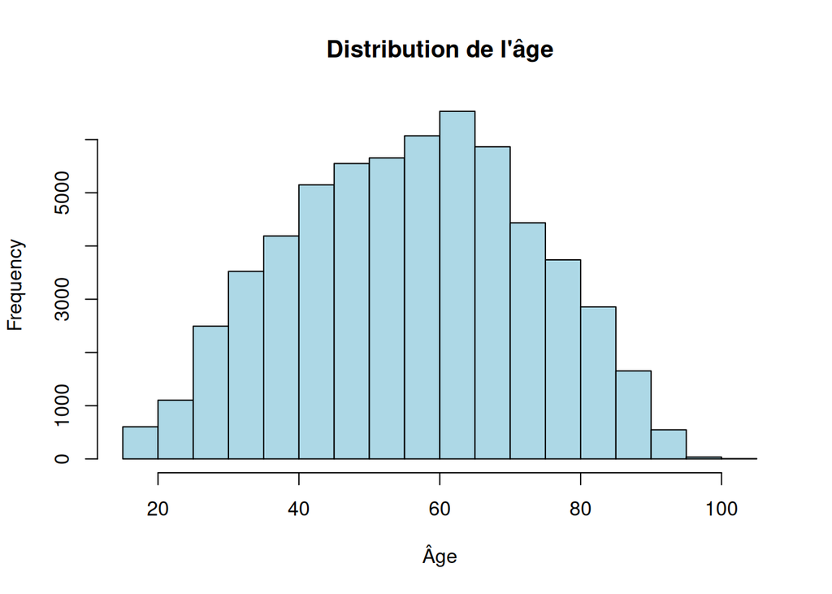

```r
hist(df$age,
     col = "lightblue",
     main = "Distribution de l'âge",
     xlab = "Âge")
```

### Distribution du salaire horaire

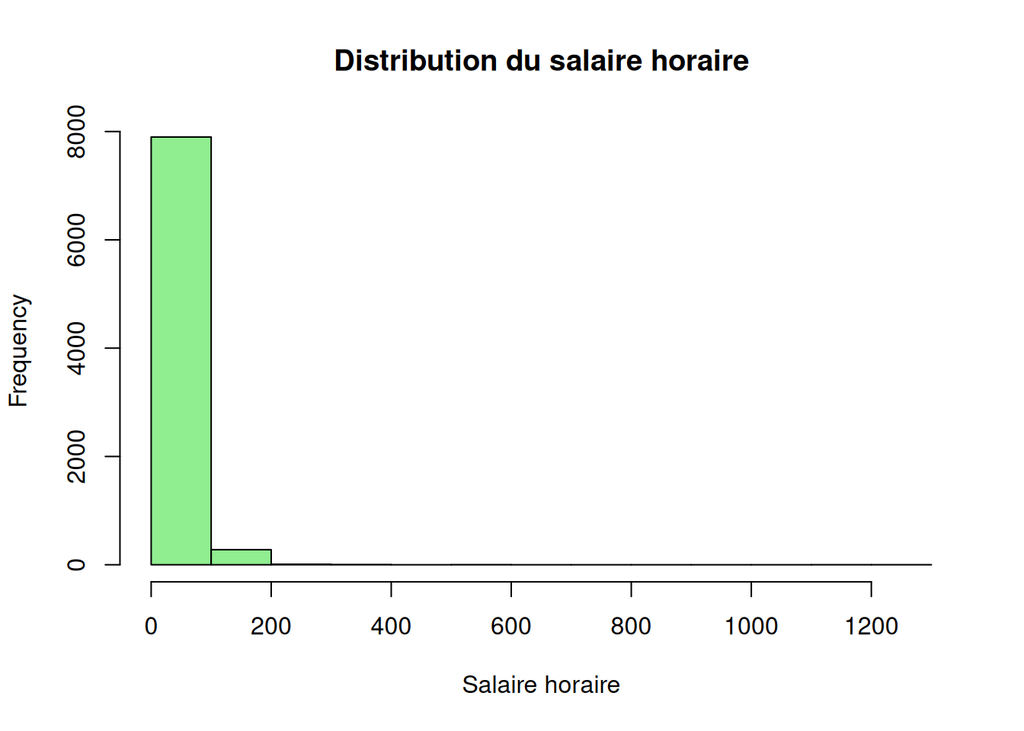

```r
hist(df$salhoraire,
     col = "lightgreen",
     main = "Distribution du salaire horaire",
     xlab = "Salaire horaire")
```

## Distribution du log salaire

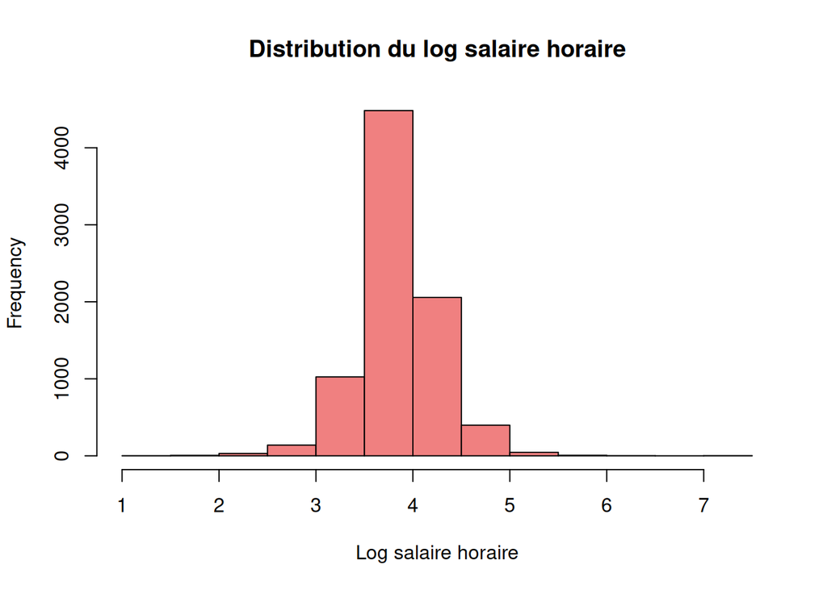

```r
hist(df$logsalhoraire,
     col = "lightcoral",
     main = "Distribution du log salaire horaire",
     xlab = "Log salaire horaire")
```

### Répartition par origine

```r
  table(df$origine)
```

```
##
##    01    03    04    05    06    07    08    09    10    99
## 49230  1152  3978   978  1854   648   462   234   306  1158
```

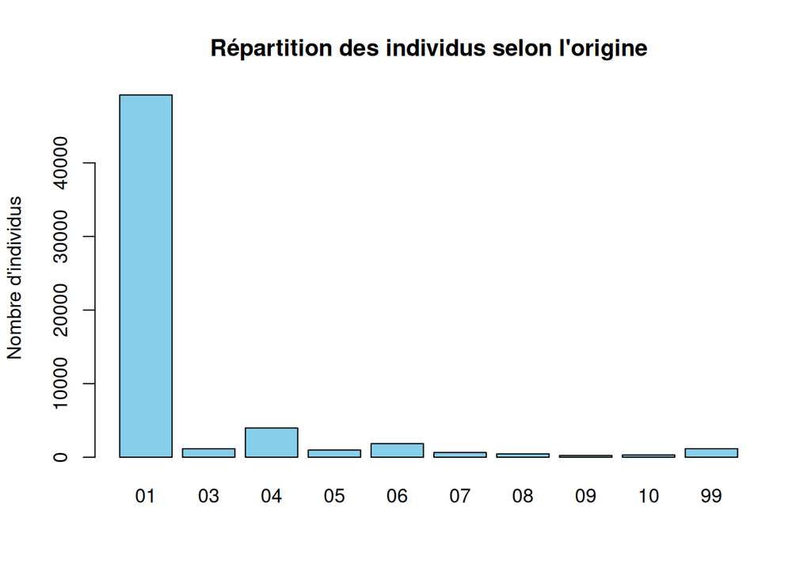

```r
barplot(table(df$origine),
        col = "skyblue",
        main = "Répartition des individus selon l'origine",
        ylab = "Nombre d'individus")
```

### Répartition par sexe

```r
table(df$homme)
```

```
##
##     0     1
## 32424 27576
```

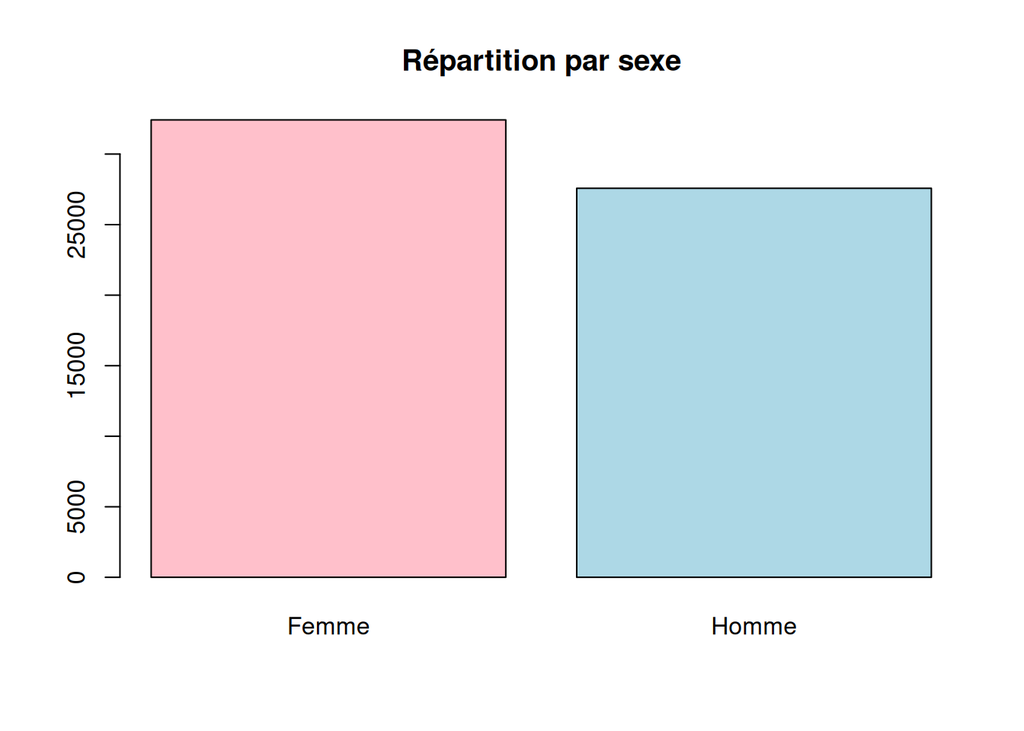

```r
barplot(table(df$homme),
        col = c("pink","lightblue"),
        main = "Répartition par sexe",
        names.arg = c("Femme","Homme"))
```

### Salaire selon l’origine

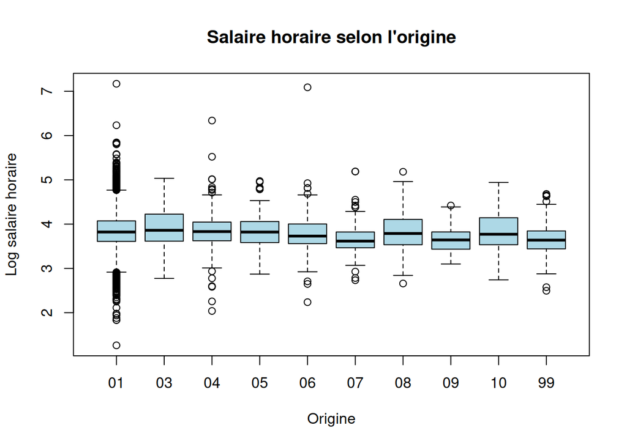

```r
boxplot(logsalhoraire ~ origine,
        data = df,
        col = "lightblue",
        main = "Salaire horaire selon l'origine",
        xlab = "Origine",
        ylab = "Log salaire horaire")
```

### Education et origine

```r
  table(df$education)
```

```
##
##           1     3     4     5     6     7
##     4  8130  6296  9439 15892  4006 16233
```

```r
prop.table(table(df$origine))
```

```
##
##     01     03     04     05     06     07     08     09     10     99
## 0.8205 0.0192 0.0663 0.0163 0.0309 0.0108 0.0077 0.0039 0.0051 0.0193
```

```r
prop.table(table(df$education))
```

```
##
##                         1            3            4            5            6
## 6.666667e-05 1.355000e-01 1.049333e-01 1.573167e-01 2.648667e-01 6.676667e-02
##            7
## 2.705500e-01
```

```r
table_data <- table(df$education, df$origine)
table(df$education, df$origine)
```

```
##
##        01    03    04    05    06    07    08    09    10    99
##         4     0     0     0     0     0     0     0     0     0
##   1  6613   270   337   186   252   121   113    36   118    84
##   3  5415   108   299   129   150    66    43     6    44    36
##   4  7944   144   485   141   213   122   114    42    54   180
##   5 13640   240   958   180   354   120    40    30    18   312
##   6  3323    78   256    66    73    48     6    18     6   132
##   7 12291   312  1643   276   812   171   146   102    66   414
```

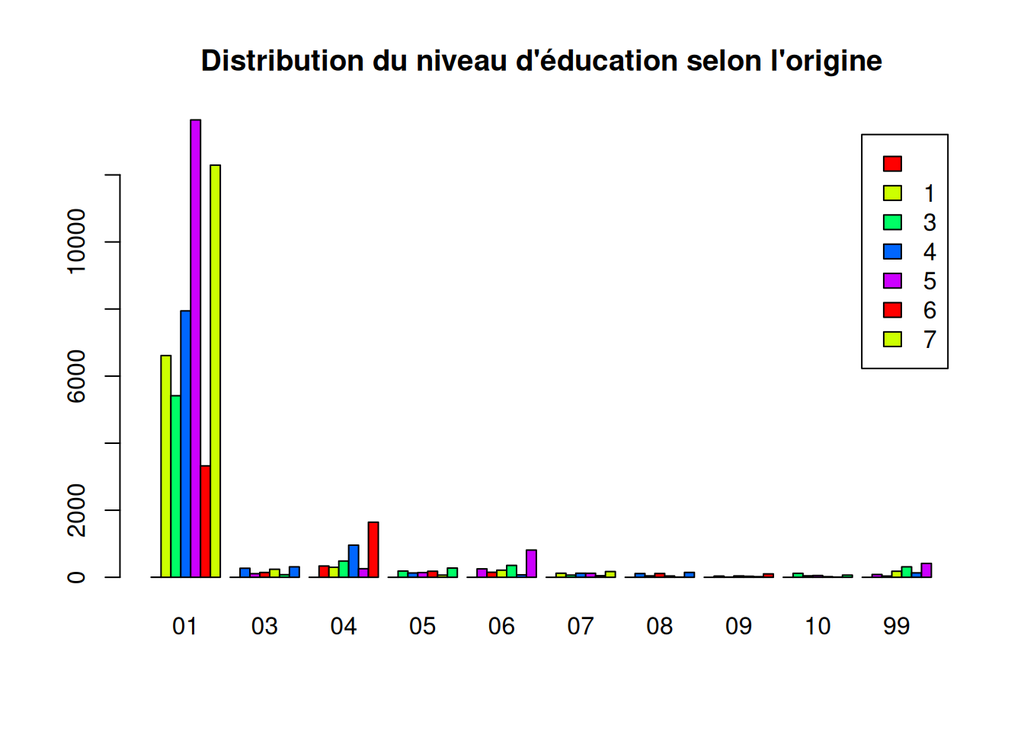

```r
table_data <- table(df$education, df$origine)

barplot(table_data,
        beside = TRUE,
        col = rainbow(5),
        legend = TRUE,
        main = "Distribution du niveau d'éducation selon l'origine")
```

### Statistiques par groupe (par origine)

```r
df %>%
  group_by(origine) %>%
  summarise(
    salaire_moyen = mean(salhoraire, na.rm = TRUE),
    logsalaire_moyen = mean(logsalhoraire, na.rm = TRUE),
    age_moyen = mean(age, na.rm = TRUE),
    n = n()
  )
```

```
## # A tibble: 10 × 5
##    origine salaire_moyen logsalaire_moyen age_moyen     n
##    <chr>           <dbl>            <dbl>     <dbl> <int>
##  1 01               51.2             3.85      56.6 49230
##  2 03               56.5             3.94      60.9  1152
##  3 04               50.8             3.84      59.4  3978
##  4 05               51.3             3.85      60.2   978
##  5 06               51.1             3.79      49.7  1854
##  6 07               42.3             3.66      42.6   648
##  7 08               52.4             3.85      46.2   462
##  8 09               40.7             3.65      53.5   234
##  9 10               51.1             3.82      45.4   306
## 10 99               42.4             3.67      54.2  1158
```

## Interprétation globale des statistiques descriptives

La distribution des individus selon l’origine montre que la grande majorité de l’échantillon appartient à la catégorie d’origine française, représentant plus de 80 % des observations, tandis que les autres groupes d’origine constituent des parts beaucoup plus faibles de la population observée. La répartition par sexe apparaît relativement équilibrée entre hommes et femmes.

Ces différences observées restent toutefois purement descriptives et ne permettent pas d’interpréter un effet causal de l’origine sur le salaire, car elles ne tiennent pas compte d’autres caractéristiques individuelles susceptibles d’influencer la rémunération, telles que l’âge, le sexe, l’éducation ou la localisation géographique.

Afin d’étudier plus rigoureusement ces écarts, la section suivante propose d’estimer des modèles économétriques du salaire horaire en fonction de l’origine et d’un ensemble de variables de contrôle. L’objectif est d’évaluer si des différences salariales persistent entre groupes d’origine **toutes choses égales par ailleurs**.

# I) Marge intensive (salaire net horaire)

## Question 1 – Effet de l’origine sur le salaire horaire

Dans cette première partie, on s’intéresse à l’existence d’éventuelles inégalités salariales liées à l’origine des individus. Conformément à l’énoncé, on se restreint aux individus **actifs occupés** et on utilise uniquement **le dernier trimestre observé**, ce qui revient à travailler sur une coupe transversale des données.

La variable dépendante considérée est le **salaire net horaire** (`salhoraire`) ou le **logarithme du salaire net horaire** (`logsalhoraire`). L’utilisation du logarithme est courante dans l’analyse des salaires car elle permet de réduire l’asymétrie de la distribution et d’interpréter les coefficients comme des variations relatives.

L’objectif est d’estimer l’effet de la variable **origine** sur le salaire, tout en introduisant progressivement des variables de contrôle afin d’approcher la notion de comparaison **toutes choses égales par ailleurs**. Plusieurs spécifications sont donc estimées :

- un premier modèle incluant uniquement la variable **origine**, afin d’observer les écarts salariaux bruts entre groupes ;
- un second modèle ajoutant des variables démographiques (âge, âge au carré, sexe) permettant de contrôler pour le cycle de vie et les différences entre hommes et femmes ;
- un troisième modèle intégrant des variables géographiques (région et type d’unité urbaine) afin de tenir compte des différences territoriales du marché du travail ;
- un quatrième modèle incluant le **niveau d’éducation**, variable centrale du capital humain ;
- enfin un modèle plus complet intégrant également certaines caractéristiques de l’emploi, telles que la catégorie socio-professionnelle et le type de contrat.

Cette stratégie permet d’analyser comment évoluent les coefficients associés à l’origine lorsque l’on introduit progressivement des variables susceptibles d’expliquer les écarts de salaire observés.

```r
df1 <- df %>%
  filter(t == 6, acteu == 1)%>%
  mutate(
    age2  = age^2
  ) %>%
  droplevels()


regression <- function(y, data = df1){

  # On convertit l'argument en caractère si c'est un nom non cité
  y <- deparse(substitute(y))

  # Définition des listes de variables explicatives
  rhs1 <- "origine"
  rhs2 <- c(rhs1, "age", "age2", "homme")
  rhs3 <- c(rhs2, "region", "tuu_r")
  rhs4 <- c(rhs3, "education")
  rhs5 <- c(rhs4, "csp_actif", "contrat")

  # Estimation des modèles avec reformulate()
  m1 <- lm_robust(reformulate(rhs1, y), data = data)
  m2 <- lm_robust(reformulate(rhs2, y), data = data)
  m3 <- lm_robust(reformulate(rhs3, y), data = data)
  m4 <- lm_robust(reformulate(rhs4, y), data = data)
  m5 <- lm_robust(reformulate(rhs5, y), data = data)

  # On regroupe pour le tableau
  models <- list(
    "modèle(1)" = m1,
    "modèle(2)" = m2,
    "modèle(3)" = m3,
    "modèle(4)" = m4,
    "modèle(5)" = m5
  )

  # Rendu du tableau
  modelsummary(
    models,
    stars = TRUE,
    coef_omit = "Intercept",
    gof_omit = "AIC|BIC|Log.Lik|F|Std.Errors",
    title = paste("Analyse de la variable :", y),
    notes = "Écarts-types robustes (HC2)."
  )

}

  # a) Modèle LOG
regression(logsalhoraire)
```

Analyse de la variable : logsalhoraire

|  | modèle(1) | modèle(2) | modèle(3) | modèle(4) | modèle(5) |
| --- | --- | --- | --- | --- | --- |
| origine03 | 0.120* | 0.123* | 0.121* | 0.078+ | 0.105* |
|  | (0.052) | (0.050) | (0.050) | (0.044) | (0.043) |
| origine04 | -0.004 | -0.007 | -0.028 | 0.036 | 0.051* |
|  | (0.026) | (0.025) | (0.026) | (0.024) | (0.023) |
| origine05 | -0.023 | -0.038 | -0.054 | -0.097+ | -0.026 |
|  | (0.056) | (0.052) | (0.052) | (0.053) | (0.045) |
| origine06 | -0.041 | -0.050+ | -0.104** | -0.039 | -0.009 |
|  | (0.031) | (0.030) | (0.032) | (0.029) | (0.024) |
| origine07 | -0.178*** | -0.153*** | -0.222*** | -0.155** | -0.067+ |
|  | (0.048) | (0.046) | (0.045) | (0.048) | (0.041) |
| origine08 | 0.095 | 0.104 | 0.051 | 0.081 | 0.090 |
|  | (0.083) | (0.078) | (0.076) | (0.062) | (0.062) |
| origine09 | -0.184* | -0.155* | -0.169* | -0.054 | -0.040 |
|  | (0.079) | (0.071) | (0.078) | (0.064) | (0.057) |
| origine10 | -0.010 | -0.001 | -0.028 | -0.083 | -0.045 |
|  | (0.099) | (0.096) | (0.101) | (0.080) | (0.075) |
| origine99 | -0.140** | -0.134** | -0.154*** | -0.070+ | -0.046 |
|  | (0.046) | (0.044) | (0.043) | (0.039) | (0.036) |
| age |  | 0.028*** | 0.029*** | 0.027*** | 0.016** |
|  |  | (0.006) | (0.006) | (0.006) | (0.006) |
| age2 |  | -0.000*** | -0.000*** | -0.000** | -0.000+ |
|  |  | (0.000) | (0.000) | (0.000) | (0.000) |
| homme |  | 0.134*** | 0.136*** | 0.164*** | 0.101*** |
|  |  | (0.012) | (0.012) | (0.011) | (0.011) |
| region |  |  | -0.004+ | -0.000 | -0.001 |
|  |  |  | (0.002) | (0.002) | (0.002) |
| tuu_r2 |  |  | -0.033+ | -0.030+ | -0.028+ |
|  |  |  | (0.017) | (0.016) | (0.015) |
| tuu_r3 |  |  | 0.015 | -0.002 | 0.002 |
|  |  |  | (0.018) | (0.016) | (0.015) |
| tuu_r4 |  |  | 0.059*** | 0.004 | -0.010 |
|  |  |  | (0.017) | (0.016) | (0.015) |
| tuu_r5 |  |  | 0.150*** | 0.095*** | 0.046* |
|  |  |  | (0.025) | (0.022) | (0.021) |
| education3 |  |  |  | -0.135*** | -0.032+ |
|  |  |  |  | (0.019) | (0.018) |
| education4 |  |  |  | -0.264*** | -0.087*** |
|  |  |  |  | (0.019) | (0.019) |
| education5 |  |  |  | -0.391*** | -0.147*** |
|  |  |  |  | (0.017) | (0.020) |
| education6 |  |  |  | -0.406*** | -0.157*** |
|  |  |  |  | (0.027) | (0.027) |
| education7 |  |  |  | -0.515*** | -0.240*** |
|  |  |  |  | (0.022) | (0.025) |
| csp_actif3 |  |  |  |  | 0.928 |
|  |  |  |  |  | (0.820) |
| csp_actif4 |  |  |  |  | 0.710 |
|  |  |  |  |  | (0.820) |
| csp_actif5 |  |  |  |  | 0.501 |
|  |  |  |  |  | (0.820) |
| csp_actif6 |  |  |  |  | 0.558 |
|  |  |  |  |  | (0.820) |
| contrat0 |  |  |  |  | -0.019 |
|  |  |  |  |  | (0.124) |
| contrat1 |  |  |  |  | -0.083 |
|  |  |  |  |  | (0.124) |
| contrat2 |  |  |  |  | -0.249+ |
|  |  |  |  |  | (0.127) |
| contrat3 |  |  |  |  | -0.261+ |
|  |  |  |  |  | (0.148) |
| contrat4 |  |  |  |  | -0.118 |
|  |  |  |  |  | (0.133) |
| contrat5 |  |  |  |  | -0.482** |
|  |  |  |  |  | (0.184) |
| Num.Obs. | 4046 | 4046 | 4046 | 4046 | 4046 |
| R2 | 0.008 | 0.062 | 0.083 | 0.251 | 0.361 |
| R2 Adj. | 0.006 | 0.059 | 0.079 | 0.247 | 0.356 |
| RMSE | 0.40 | 0.39 | 0.38 | 0.35 | 0.32 |

+ p < 0.1, * p < 0.05, ** p < 0.01, *** p < 0.001  
Écarts-types robustes (HC2).

```r
# a) Modèle en niveau
regression(salhoraire)
```

Analyse de la variable : salhoraire

|  | modèle(1) | modèle(2) | modèle(3) | modèle(4) | modèle(5) |
| --- | --- | --- | --- | --- | --- |
| origine03 | 6.340+ | 6.321* | 6.187+ | 3.456 | 4.691 |
|  | (3.277) | (3.213) | (3.160) | (2.854) | (2.918) |
| origine04 | 0.238 | 0.241 | -1.026 | 2.365 | 3.135 |
|  | (2.524) | (2.550) | (2.620) | (2.534) | (2.504) |
| origine05 | -1.316 | -2.433 | -3.364 | -5.684* | -1.836 |
|  | (3.161) | (2.830) | (2.780) | (2.876) | (2.484) |
| origine06 | -3.256+ | -3.617* | -6.774*** | -3.483* | -1.953 |
|  | (1.724) | (1.722) | (1.867) | (1.718) | (1.442) |
| origine07 | -8.400** | -7.122* | -11.078*** | -7.714** | -3.451 |
|  | (2.979) | (2.864) | (2.801) | (2.890) | (2.441) |
| origine08 | 6.959 | 8.170 | 5.107 | 6.190 | 6.359 |
|  | (6.184) | (5.966) | (5.800) | (4.998) | (4.915) |
| origine09 | -9.970** | -8.547** | -9.627** | -3.898 | -3.127 |
|  | (3.494) | (3.177) | (3.627) | (2.730) | (2.553) |
| origine10 | 1.480 | 2.425 | 0.891 | -2.704 | -0.983 |
|  | (5.755) | (5.652) | (5.920) | (4.867) | (4.453) |
| origine99 | -6.839** | -6.825** | -7.889*** | -3.408+ | -2.334 |
|  | (2.257) | (2.149) | (2.065) | (1.816) | (1.625) |
| age |  | 0.294 | 0.363 | 0.315 | -0.198 |
|  |  | (0.644) | (0.654) | (0.642) | (0.665) |
| age2 |  | 0.001 | 0.000 | 0.003 | 0.006 |
|  |  | (0.008) | (0.008) | (0.007) | (0.008) |
| homme |  | 6.891*** | 6.965*** | 8.505*** | 5.456*** |
|  |  | (0.748) | (0.744) | (0.704) | (0.696) |
| region |  |  | -0.264* | -0.088 | -0.113 |
|  |  |  | (0.121) | (0.113) | (0.109) |
| tuu_r2 |  |  | -1.427 | -1.278 | -1.213 |
|  |  |  | (1.078) | (1.023) | (0.988) |
| tuu_r3 |  |  | 0.364 | -0.613 | -0.369 |
|  |  |  | (1.028) | (0.946) | (0.896) |
| tuu_r4 |  |  | 3.798*** | 0.567 | -0.354 |
|  |  |  | (1.100) | (1.022) | (0.983) |
| tuu_r5 |  |  | 8.631*** | 5.336*** | 2.605+ |
|  |  |  | (1.672) | (1.523) | (1.464) |
| education3 |  |  |  | -9.569*** | -3.479** |
|  |  |  |  | (1.348) | (1.270) |
| education4 |  |  |  | -16.427*** | -6.680*** |
|  |  |  |  | (1.229) | (1.233) |
| education5 |  |  |  | -23.278*** | -10.038*** |
|  |  |  |  | (1.120) | (1.213) |
| education6 |  |  |  | -24.194*** | -10.929*** |
|  |  |  |  | (1.675) | (1.691) |
| education7 |  |  |  | -27.568*** | -12.766*** |
|  |  |  |  | (1.439) | (1.524) |
| csp_actif3 |  |  |  |  | 32.910 |
|  |  |  |  |  | (25.174) |
| csp_actif4 |  |  |  |  | 18.342 |
|  |  |  |  |  | (25.153) |
| csp_actif5 |  |  |  |  | 9.259 |
|  |  |  |  |  | (25.148) |
| csp_actif6 |  |  |  |  | 11.021 |
|  |  |  |  |  | (25.165) |
| contrat0 |  |  |  |  | -8.377 |
|  |  |  |  |  | (12.912) |
| contrat1 |  |  |  |  | -10.808 |
|  |  |  |  |  | (12.962) |
| contrat2 |  |  |  |  | -17.918 |
|  |  |  |  |  | (13.174) |
| contrat3 |  |  |  |  | -17.781 |
|  |  |  |  |  | (13.439) |
| contrat4 |  |  |  |  | -11.692 |
|  |  |  |  |  | (13.189) |
| contrat5 |  |  |  |  | -26.974+ |
|  |  |  |  |  | (14.659) |
| Num.Obs. | 4046 | 4046 | 4046 | 4046 | 4046 |
| R2 | 0.006 | 0.046 | 0.065 | 0.200 | 0.279 |
| R2 Adj. | 0.004 | 0.043 | 0.061 | 0.196 | 0.273 |
| RMSE | 24.72 | 24.21 | 23.97 | 22.17 | 21.05 |

+ p < 0.1, * p < 0.05, ** p < 0.01, *** p < 0.001  
Écarts-types robustes (HC2).

## Question 2 : Effet du niveau de diplôme et variables instrumentales

Dans cette question, nous incluons le **niveau de diplôme** comme variable de contrôle pour mieux expliquer les différences de salaire observées. Cette inclusion soulève des questions d’endogénéité et nécessite éventuellement l’utilisation de variables instrumentales.

### a) Problème potentiel et impact sur le coefficient “origine”

Le niveau de diplôme résulte en partie d’un **choix individuel** influencé par des caractéristiques non observées (motivation, capacité cognitive, réseau familial, etc.).  
Inclure directement `education` dans le modèle peut entraîner :

- **Biais d’endogénéité** : le coefficient de `education` capte des effets non observables corrélés avec le salaire.
- **Biais sur l’estimation de l’effet de l’origine** : si certaines origines ont des distributions d’éducation différentes, le coefficient `origine` pourrait être **sous-estimé ou sur-estimé**, selon la corrélation entre origine et éducation.

### b) Choix des instruments

Cet instrument est **relevant** (corrélés avec le diplôme) et **valide** (non corrélés avec l’erreur du modèle salarial).

```r
df1 <- df1 %>%
  mutate(
    # Instrument : le parent ayant la plus haute CSP
    csp_max = pmax(csp_mere, csp_pere, na.rm = TRUE) %>% as.factor()
  )
          #--------Pertinence----------
m_iv <- iv_robust(
  logsalhoraire ~ origine + age + age2 + homme + region + tuu_r + education |
    origine + age + age2 + homme + region + tuu_r + csp_mere,
  data = df1,
  diagnostics = TRUE # TRÈS IMPORTANT pour avoir le F-test
)

summary(m_iv)
```

```
##
## Call:
## iv_robust(formula = logsalhoraire ~ origine + age + age2 + homme +
##     region + tuu_r + education | origine + age + age2 + homme +
##     region + tuu_r + csp_mere, data = df1, diagnostics = TRUE)
##
## Standard error type:  HC2
##
## Coefficients:
##               Estimate Std. Error t value  Pr(>|t|)   CI Lower   CI Upper   DF
## (Intercept)  3.1947186  1.745e-01 18.3111 5.269e-72  2.8526634  3.537e+00 4023
## origine03    0.0769272  4.860e-02  1.5828 1.135e-01 -0.0183603  1.722e-01 4023
## origine04    0.0532342  3.351e-02  1.5887 1.122e-01 -0.0124590  1.189e-01 4023
## origine05   -0.0971312  5.949e-02 -1.6326 1.026e-01 -0.2137734  1.951e-02 4023
## origine06   -0.0053161  3.659e-02 -0.1453 8.845e-01 -0.0770596  6.643e-02 4023
## origine07   -0.1435007  6.209e-02 -2.3111 2.088e-02 -0.2652342 -2.177e-02 4023
## origine08    0.1033593  7.841e-02  1.3182 1.875e-01 -0.0503720  2.571e-01 4023
## origine09   -0.0174043  9.731e-02 -0.1789 8.581e-01 -0.2081770  1.734e-01 4023
## origine10   -0.0848880  8.911e-02 -0.9526 3.408e-01 -0.2595944  8.982e-02 4023
## origine99   -0.0713317  5.421e-02 -1.3159 1.883e-01 -0.1776061  3.494e-02 4023
## age          0.0296382  7.852e-03  3.7747 1.625e-04  0.0142442  4.503e-02 4023
## age2        -0.0002161  8.987e-05 -2.4049 1.622e-02 -0.0003923 -3.993e-05 4023
## homme        0.1781293  1.583e-02 11.2528 6.050e-29  0.1470940  2.092e-01 4023
## region       0.0007926  2.287e-03  0.3465 7.290e-01 -0.0036920  5.277e-03 4023
## tuu_r2      -0.0359253  1.823e-02 -1.9702 4.888e-02 -0.0716745 -1.762e-04 4023
## tuu_r3      -0.0057549  1.837e-02 -0.3133 7.541e-01 -0.0417671  3.026e-02 4023
## tuu_r4      -0.0117801  1.847e-02 -0.6377 5.237e-01 -0.0479948  2.443e-02 4023
## tuu_r5       0.0814329  2.835e-02  2.8725 4.094e-03  0.0258531  1.370e-01 4023
## education3  -0.1766843  1.724e-01 -1.0248 3.055e-01 -0.5146937  1.613e-01 4023
## education4  -0.1980281  1.677e-01 -1.1809 2.377e-01 -0.5267982  1.307e-01 4023
## education5  -0.5245113  1.143e-01 -4.5894 4.580e-06 -0.7485774 -3.004e-01 4023
## education6  -0.1725488  2.899e-01 -0.5953 5.517e-01 -0.7408197  3.957e-01 4023
## education7  -0.7114559  1.375e-01 -5.1727 2.420e-07 -0.9811112 -4.418e-01 4023
##
## Multiple R-squared:  0.1797 ,    Adjusted R-squared:  0.1752
## F-statistic: 24.02 on 22 and 4023 DF,  p-value: < 2.2e-16
##
## Diagnostics:
##                               numdf dendf  value p.value
## Weak instruments (education3)    31  3997 10.555  <2e-16 ***
## Weak instruments (education4)    31  3997  9.941  <2e-16 ***
## Weak instruments (education5)    31  3997 12.457  <2e-16 ***
## Weak instruments (education6)    31  3997  5.550  <2e-16 ***
## Weak instruments (education7)    31  3997  9.497  <2e-16 ***
## Wu-Hausman                        5  4018  1.790  0.1114
## Overidentifying                  26    NA 35.747  0.0964 .
## ---
## Signif. codes:  0 '***' 0.001 '**' 0.01 '*' 0.05 '.' 0.1 ' ' 1
```

```r
        #-------Estimation------------



m_ols <- lm(logsalhoraire ~ origine + age + age2 + homme + region + tuu_r + education,
            data = df1)

models_iv <- list(
  "OLS" = m_ols,
  "IV (2SLS)" = m_iv
)

modelsummary(
  models_iv,
  stars = TRUE,
  coef_omit = "Intercept",
  gof_omit = "AIC|BIC|Log.Lik|F|Std.Errors",
  title = "Comparaison MCO vs Variables Instrumentales",
  notes = "Instruments : CSP la plus haute des deux parents."
)
```

Comparaison MCO vs Variables Instrumentales

|  | OLS | IV (2SLS) |
| --- | --- | --- |
| origine03 | 0.078+ | 0.077 |
|  | (0.046) | (0.049) |
| origine04 | 0.036 | 0.053 |
|  | (0.024) | (0.034) |
| origine05 | -0.097+ | -0.097 |
|  | (0.049) | (0.059) |
| origine06 | -0.039 | -0.005 |
|  | (0.032) | (0.037) |
| origine07 | -0.155*** | -0.144* |
|  | (0.046) | (0.062) |
| origine08 | 0.081 | 0.103 |
|  | (0.064) | (0.078) |
| origine09 | -0.054 | -0.017 |
|  | (0.085) | (0.097) |
| origine10 | -0.083 | -0.085 |
|  | (0.070) | (0.089) |
| origine99 | -0.070+ | -0.071 |
|  | (0.040) | (0.054) |
| age | 0.027*** | 0.030*** |
|  | (0.004) | (0.008) |
| age2 | -0.000*** | -0.000* |
|  | (0.000) | (0.000) |
| homme | 0.164*** | 0.178*** |
|  | (0.011) | (0.016) |
| region | -0.000 | 0.001 |
|  | (0.002) | (0.002) |
| tuu_r2 | -0.030+ | -0.036* |
|  | (0.016) | (0.018) |
| tuu_r3 | -0.002 | -0.006 |
|  | (0.017) | (0.018) |
| tuu_r4 | 0.004 | -0.012 |
|  | (0.015) | (0.018) |
| tuu_r5 | 0.095*** | 0.081** |
|  | (0.022) | (0.028) |
| education3 | -0.135*** | -0.177 |
|  | (0.018) | (0.172) |
| education4 | -0.264*** | -0.198 |
|  | (0.018) | (0.168) |
| education5 | -0.391*** | -0.525*** |
|  | (0.017) | (0.114) |
| education6 | -0.406*** | -0.173 |
|  | (0.027) | (0.290) |
| education7 | -0.515*** | -0.711*** |
|  | (0.021) | (0.138) |
| Num.Obs. | 4046 | 4046 |
| R2 | 0.251 | 0.180 |
| R2 Adj. | 0.247 | 0.175 |
| RMSE | 0.35 | 0.36 |